[GitHub](https://github.com/agate-model/Agate.jl)[](https://github.com/agate-model/Agate.jl/blob/main/examples/reverse_mode_ad_nipizd_sensitivity.jl)

# Reverse-mode AD sensitivity

This example differentiates the final total phytoplankton biomass in the default NiPiZD model with respect to several active parameters at once. The active parameter vector includes a scalar parameter, plankton-axis vector parameters, and predator-by-prey interaction matrix entries.

```julia
using Agate
using Agate.Library.Light: CyclicalPAR
using ADTypes: AutoEnzyme
using CairoMakie
import DifferentiationInterface
using Enzyme
using OrdinaryDiffEq: Tsit5, solve
using SciMLBase: remake
using SciMLSensitivity

using Oceananigans.Biogeochemistry: required_biogeochemical_tracers
using Oceananigans.Units: day

const NiPiZD = Agate.Models.NiPiZD
```

## Static model and active parameter map

To run a model sensitivity analysis, we first choose the parameters that we want to vary: the active parameters.

Here we vary parameters controlling phytoplankton growth, detritus recycling, grazing preferences, and grazing efficiency. We then measure how changes in each parameter affect the final total phytoplankton biomass.

```julia
const BGC = NiPiZD.construct()
const TRACER_NAMES = Tuple(required_biogeochemical_tracers(BGC))
const PLANKTON_PFTS = Agate.Introspection.pfts(BGC)

function tracer_index(tracer::Symbol)
    index = findfirst(==(tracer), TRACER_NAMES)
    isnothing(index) && error("Tracer $tracer not found in $TRACER_NAMES")
    return index
end

const PHYTOPLANKTON = PLANKTON_PFTS.P
const PHYTOPLANKTON_INDICES = tracer_index.(PHYTOPLANKTON)

const ACTIVE = Agate.Runtime.active_parameters(BGC;
    maximum_growth_rate = (:P_1, :P_2),
    detritus_remineralization = true,
    palatability_matrix = ((:Z_1, :P_1), (:Z_1, :P_2), (:Z_2, :P_1)),
    assimilation_matrix = ((:Z_1, :P_1),),
)
const PARAMETER_LABELS = ACTIVE.labels

const θ_REFERENCE = copy(ACTIVE.values)

const SAVEAT = collect(range(0.0, 30day; length = 31))
const TSPAN = (first(SAVEAT), last(SAVEAT))
const PAR = CyclicalPAR(-10)

const INITIAL_CONCENTRATIONS = (; N = 7.0, D = 0.01,
                                 Z_1 = 0.01, Z_2 = 0.01,
                                 P_1 = 0.01, P_2 = 0.1)

function initial_conditions(::Type{T}) where {T}
    return T[getproperty(INITIAL_CONCENTRATIONS, tracer) for tracer in TRACER_NAMES]
end

function nipizd_problem(theta)
    T = eltype(theta)

    return Agate.Runtime.ode_problem(
        BGC,
        initial_conditions(T),
        TSPAN;
        p = theta,
        active_parameters = ACTIVE,
        auxiliary = (; PAR = t -> PAR(T(t))),
    )
end

const PROBLEM = nipizd_problem(θ_REFERENCE)
```

## Endpoint objective

We measure sensitivity using the final total phytoplankton biomass after a short model run. The gradient tells us how strongly each active parameter affects that final biomass near the reference parameter values.

```julia
const SENSEALG = SciMLSensitivity.GaussAdjoint(
    autojacvec = SciMLSensitivity.EnzymeVJP(),
)

function solve_values(theta; sensealg = nothing, saveat = SAVEAT,
                      save_start = true, save_end = true, save_everystep = false)
    problem = remake(PROBLEM; p = theta)
    kwargs = (; abstol = 1e-8, reltol = 1e-8, verbose = false,
              saveat, save_start, save_end, save_everystep)

    sol = isnothing(sensealg) ? solve(problem, Tsit5(); kwargs...) :
                                solve(problem, Tsit5(); kwargs..., sensealg)

    return Array(sol)
end

function solve_final_values(theta; sensealg = nothing)
    values = solve_values(theta;
                          sensealg,
                          saveat = TSPAN[end],
                          save_start = false,
                          save_end = true,
                          save_everystep = false)

    return values[:, end]
end

function total_phytoplankton(values)
    total = zero(eltype(values))

    for i in PHYTOPLANKTON_INDICES
        total += values[i]
    end

    return total
end

function final_total_phytoplankton(theta; sensealg = nothing)
    return total_phytoplankton(solve_final_values(theta; sensealg))
end

final_total_phytoplankton_adjoint(theta) = final_total_phytoplankton(theta; sensealg = SENSEALG)
```

## Enzyme gradient through DifferentiationInterface

DifferentiationInterface provides a common gradient API for several Julia AD backends. This example uses `AutoEnzyme`, which uses Enzyme.jl as the reverse-mode backend.

Parameters can have different units and magnitudes, so raw gradients are not always easy to compare. We rank sensitivities visually by `|θᵢ ∂J/∂θᵢ|`, which estimates how much each parameter contributes relative to its reference value.

```julia
const AD_BACKEND = AutoEnzyme(; mode = Enzyme.set_runtime_activity(Enzyme.Reverse))

enzyme_gradient(theta) = DifferentiationInterface.gradient(final_total_phytoplankton_adjoint,
                                                           AD_BACKEND,
                                                           theta)

function diagnostic_plots(reference_values, scaled_sensitivities, order)
    days = SAVEAT ./ day

    trajectory_fig = Figure()
    ax = Axis(trajectory_fig[1, 1],
              xlabel = "Time (days)",
              ylabel = "Total phytoplankton")
    phytoplankton = vec(sum(reference_values[PHYTOPLANKTON_INDICES, :]; dims = 1))
    lines!(ax, days, phytoplankton)

    plot_order = reverse(order)

    sensitivity_fig = Figure(size = (800, 400))
    ax = Axis(sensitivity_fig[1, 1],
              xlabel = "|θᵢ ∂J/∂θᵢ|",
              yticks = (1:length(plot_order), collect(PARAMETER_LABELS)[plot_order]))
    barplot!(ax, scaled_sensitivities[plot_order]; direction = :x)

    return (; trajectory = trajectory_fig, scaled_sensitivities = sensitivity_fig)
end

reference_values = solve_values(θ_REFERENCE)
gradient = enzyme_gradient(copy(θ_REFERENCE))
scaled_sensitivities = abs.(θ_REFERENCE .* gradient)
sensitivity_order = sortperm(scaled_sensitivities; rev = true)

plots = diagnostic_plots(reference_values, scaled_sensitivities, sensitivity_order)
```

```
(trajectory = Scene(1 children, 0 plots), scaled_sensitivities = Scene(1 children, 0 plots))
```

The reference trajectory shows the simulated total phytoplankton biomass used for the endpoint sensitivity calculation.

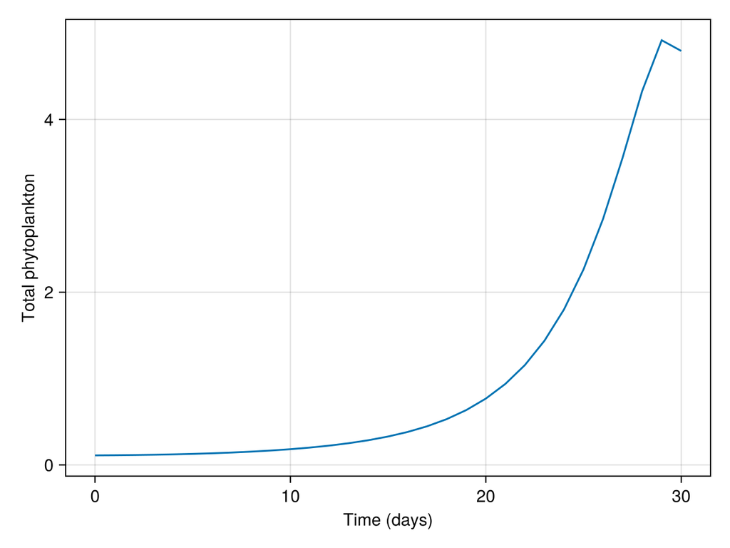

```julia
plots.trajectory
```

The scaled sensitivities rank active parameters by `|θᵢ ∂J/∂θᵢ|`.

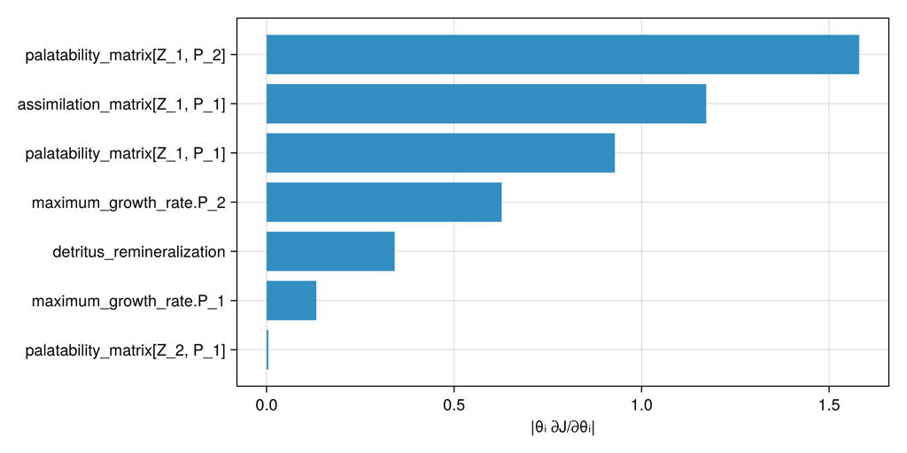

```julia
plots.scaled_sensitivities
```

*This page was generated using Literate.jl.*